# R-intro - Session 2

# Analyzing distributions

## Exploratory data analysis for visualizing distributions

Boxplots are a graphical representation of the five number summary, depicting quartiles (i.e. the 25%, 50%, and 75% quantiles), minimum, maximum and outliers (if present).

Boxplots convey the shape of the data distribution, the presence of extreme values, and the ability to compare with other variables using the same scale, providing an excellent tool for screening data, determining thresholds for variables and developing working hypotheses.

### Exercise 4

4. In this exercise we will continue our exploration of the `iris` dataset and analyze differences in the distribution of different leaf structures between species.
1. Using a formula in the `boxplot` function (i.e. `variable ~ group`) make a plot for each one of the variables by species:
- `Sepal.Length`
- `Sepal.Width`
- `Petal.Length`
- `Petal.Width`
2. Using the plots from the previous exercise, try to answer the following questions by visual interpretation:
3. Overall, which leaf structure seems to separate better the species: sepals or petals?
2. Which variable better differentiates *Iris setosa* from the two other species?
3. Overall, which variable seems to perform worst in terms of species differentiation?

## Hypothesis testing

Two-sample (unpaired) *t-tests* are often used to compare the means from two different groups of data under the assumption that both samples are random, independent, and come from normally distributed populations with unknown variances.

This test can help to verify if means are significantly different from one another. In that case, we can say that the variable being manipulated (the independent variable), had an effect on the variable being measured (the dependent variable).

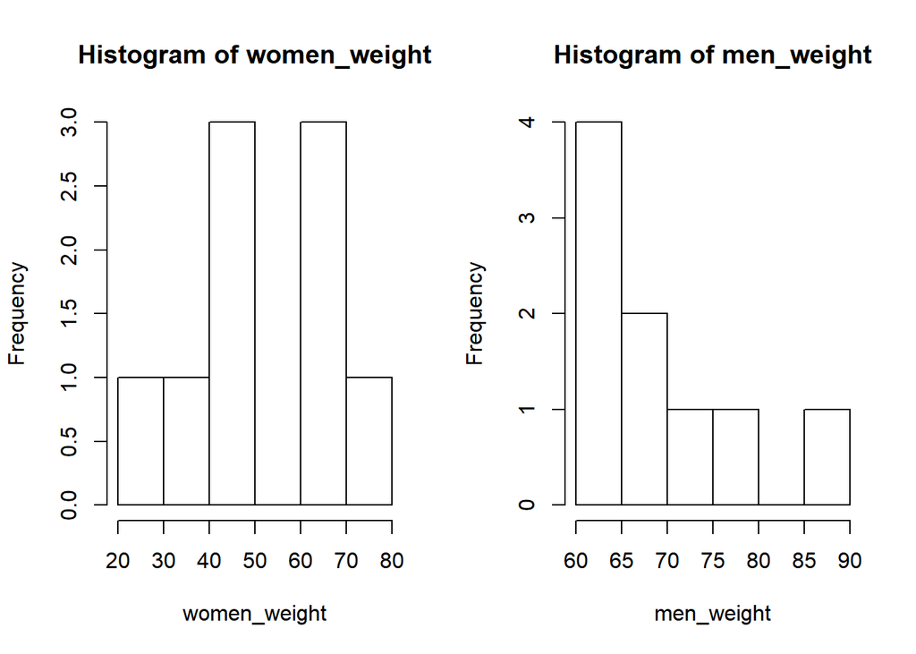

```r
# In this example we will test the null hypothesis (H0) that the average for the men's weight is equal to the women's:
# H0: AVG(m) = AVG(w)
#
# Therefore the alternative hypothesis (Ha) is that of difference between the means:
# Ha: AVG(m) != AVG(w)
#

women_weight <- c(38.9, 61.2, 73.3, 21.8, 63.4, 64.6, 48.4, 48.8, 48.5)
men_weight <- c(67.8, 60, 63.4, 76, 89.4, 73.3, 67.3, 61.3, 62.4)

# Histogram
par(mfrow = c(1,2))
hist(women_weight)
hist(men_weight)
```

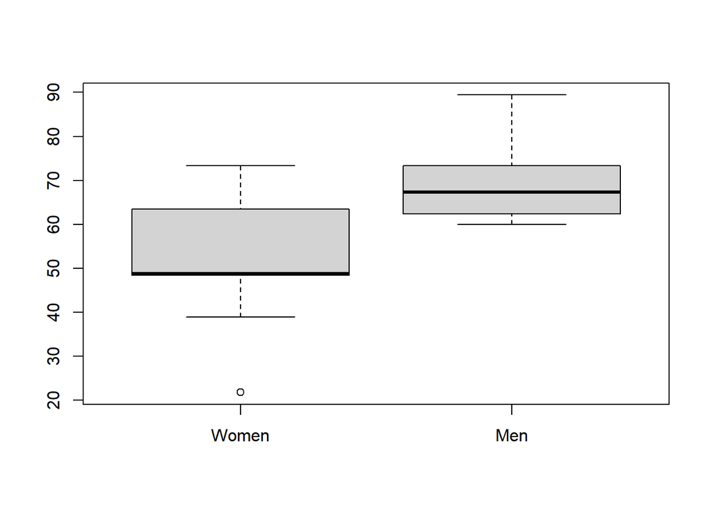

```r
# Boxplot
par(mfrow = c(1,1))
boxplot(list(Women=women_weight, Men=men_weight), col="light grey")
```

```r
# Two-sample unpaired t-Test
t.test(women_weight, men_weight)
```

```
##
##  Welch Two Sample t-test
##
## data:  women_weight and men_weight
## t = -2.7842, df = 13.114, p-value = 0.01538
## alternative hypothesis: true difference in means is not equal to 0
## 95 percent confidence interval:
##  -29.981920  -3.795858
## sample estimates:
## mean of x mean of y
##  52.10000  68.98889
```

Given that our p-value is below 0.05, we can reject the null hypothesis of average equality.

### Exercise 5

5. Using the `PlantGrowth` dataset, containing results of an experiment used to compare yields (dried weight of plants) obtained under a control and two different treatment conditions. `PlantGrowth` contains a data frame of 30 cases on 2 variables.

[, 1] *weight* (numeric) [, 2] *group* (factor)

The levels of group are ‘ctrl’ (control), ‘trt1’, and ‘trt2’ (treatments 1 and 2).

1. Make a boxplot for comparing the distribution of the weight by group
2. Use a t-test to check if the is a difference between the control group and treatment 1
3. Use a t-test to check if the is a difference between the control group and treatment 1

## Analysis of variance (one-way)

*ANalysis Of VAriance* (ANOVA), is a widely used method designed for comparing differences in means among three or more groups.

For example, we might be interested in comparing the average waiting times in the emergency rooms of three different hospitals. Or perhaps we have conducted a experimental trial comparing the effectiveness of five different treatments to avoid a certain pathogen.

The key is that each individual falls into a group described by a (categorical) grouping variable (e.g. treatment type and or intensity) and for each individual we measure some continuous outcome (e.g., plant status).

Although there are multiple types of ANOVA, the simplest (“one-way” ANOVA) can be thought of as a generalization of a two-sample t-test. One-way ANOVA involves testing the omnibus hypothesis that k population means are identical:

$$H0: \mu_1 = \mu_2 = ... = \mu_k$$

It is important to note that a rejection of the null hypothesis (H0) does not tell you which of the population means differ. It only tells you that there is some population whose mean is different from at least one other population (it could be that all of the means are different from one another!)

The basic idea is that if the variability between the groups is greater than the variability within the groups, then we have evidence that the differences between the groups is not simply reflecting random noise.

Quantifying the within and between group variability is typically done by calculating a *mean sum of squares* (SS): add up the squared vertical distances and divide by the degrees of freedom.

This means that we are comparing the:

- *between sum of squares (BSS)*: the squared distances from the group means (average over all individuals separately for each hospital) to the global mean (average over all individuals),

*vs.* the

- *within sum of squares (WSS)*: the squared distances from each individual to their group mean (average over all individuals within the same hospital).

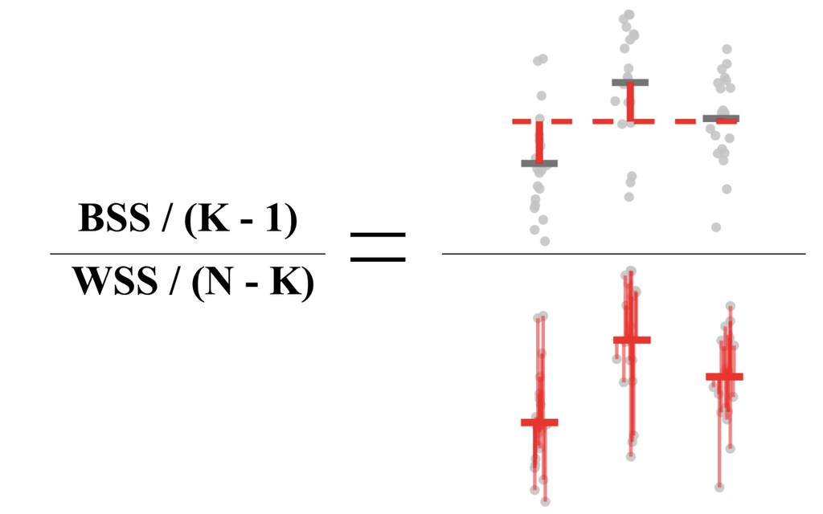

*ANOVA assumptions* are the following:

- *Assumption 1*: The samples are independent;
- *Assumption 2*: The data are normally distributed;
- *Assumption 3*: Each group has the same variance.

Using the previous `PlantGrowth` dataset we will check if there is a different between the group means using the `aov` function:

```r
res.aov <- aov(weight ~ group, data = PlantGrowth)

summary(res.aov)
```

```
##             Df Sum Sq Mean Sq F value Pr(>F)
## group        2  3.766  1.8832   4.846 0.0159 *
## Residuals   27 10.492  0.3886
## ---
## Signif. codes:  0 '***' 0.001 '**' 0.01 '*' 0.05 '.' 0.1 ' ' 1
```

As the p-value is less than the significance level of 0.05, we can conclude that there are significant differences between the groups highlighted with “*" in the model summary above.

### Exercise 6

6. Using the `iris` dataset
1. Using the ANOVA function `aov` check if there are significant differences in terms of *sepal width* across iris species
2. Using the ANOVA function `aov` check if there are significant differences in terms of *petal width* across iris species

### Exercise 7

7. In this exercise we will use a sample dataset (in the `"diet.csv"` file) with information on 76 people who undertook one of three diets (referred to as diet A, B and C). There is background information such as age, gender, and height. The aim of the study was to see which diet was best for losing weight.
1. Read the data file using function `read.csv()` (hint: use the help on `?read.csv` in case of doubt)
2. Check and remove any existing missing values from the dataset
3. Convert the variable named `Diet` into a factor variable `Treatment` with three levels 1 - “Trt-A”, 2 - “Trt-B”, 3 - “Trt-C”
4. Calculate a variable named `Weight.Loss` as the difference between `weight6weeks` and `pre.weight` and add it to the data frame
5. Using one-way ANOVA check for if the differences in weight loss across treatments are significant